# Úvod do senzometrie a R

Blok 1 · cvičenia 1 – 4

Senzometria v R · SaIT

## Čo je senzometria?

- **Senzorická analýza** meria vlastnosti potravín ľudskými zmyslami.
- **Senzometria** je štatistika pre tieto merania: ako navrhnúť experiment, vyhodnotiť ho a čomu z výsledkov veriť.

Merací prístroj je **človek**: unaví sa, adaptuje, každý používa škálu inak. Preto potrebujeme štatistiku, nie len priemery.

## Cesta senzorického experimentu

**Otázka**  
líši sa nová receptúra?→**Dizajn**  
test, panel, poradie→**Hodnotenie**  
hárky, aplikácie→**Dáta**  
data.frame v R→**Analýza**  
test, model, graf→**Rozhodnutie**  
zmeniť / nechať

V tomto kurze prejdeme všetkými krokmi – od návrhu cez analýzu po interpretáciu.

## R a RStudio

**R** – jazyk a výpočtové jadro

**RStudio** – editor okolo neho:

1. editor skriptov
2. konzola
3. premenné (Environment)
4. grafy a nápoveda

```r
install.packages("sensR")  # raz
library(sensR)             # vždy
?binom.test                # nápoveda
```

Kód píšte do **skriptu**, nie do konzoly – inak analýzu nezopakujete.

## Dátové štruktúry

```r
vektor <- c(7.5, 6.9, 7.0, 7.2)            # jeden rozmer, jeden typ
matica <- matrix(1:6, nrow = 2)            # plní sa po stĺpcoch
tabulka <- data.frame(
  hodnotitel = c("H1", "H2", "H3"),
  produkt = c("A", "A", "B"),
  chut = c(7, 6, 8)
)
tabulka$chut                               # stĺpec cez $
```

```
[1] 7 6 8
```

```r
mean(tabulka$chut)
```

```
[1] 7
```

## Návrh experimentu v R

```r
plan <- expand.grid(hodnotitel = paste0("H", 1:4), produkt = c("A", "B", "C"))
set.seed(24)
plan$poradie <- ave(seq_len(nrow(plan)), plan$hodnotitel, FUN = function(x) sample(length(x)))
head(plan[order(plan$hodnotitel, plan$poradie), ], 6)
```

```
   hodnotitel produkt poradie
5          H1       B       1
9          H1       C       2
1          H1       A       3
10         H2       C       1
6          H2       B       2
2          H2       A       3
```

Každý hodnotiteľ dostane každý produkt, poradie podávania je náhodné – potláča sa tým vplyv poradia a únavy.

## KVÍZ `each` alebo `times`?

Aký vektor vráti `rep(c("A", "B"), each = 2)`?

1. `"A" "B" "A" "B"`
2. `"A" "A" "B" "B"`

**2.** `each` opakuje každý prvok, `times` celý vektor. Spolu vytvoria úplný plán hodnotiteľ × produkt.

## Modifikovaná BCG matica

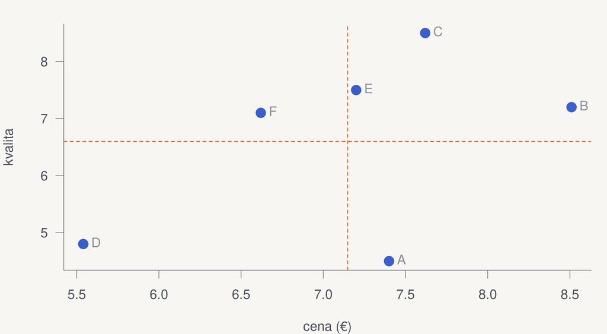

```r
cena <- c(7.40, 8.51, 7.62, 5.54, 7.20, 6.62)
kvalita <- c(4.5, 7.2, 8.5, 4.8, 7.5, 7.1)
plot(cena, kvalita, pch = 19, col = pal[3],
     cex = 1.6, xlab = "cena (€)",
     ylab = "kvalita")
abline(v = mean(cena), h = mean(kvalita),
       col = pal[2], lty = 2)
text(cena, kvalita, LETTERS[1:6], pos = 4)
```

Kvadranty podľa priemerov: vľavo hore **výhodná kúpa** (F), vpravo dole **problém** (A – drahý a najhorší).

## Interval spoľahlivosti priemeru

Priemer panelu je len **odhad**. Interval spoľahlivosti ukáže jeho neistotu:

$$\bar{x} \pm t_{0.975;\,n-1} \cdot \frac{s}{\sqrt{n}}$$

```r
x <- c(10, 9, 11, 10, 10, 9, 10)                      # 7 hodnotiteľov
delta <- sd(x) / sqrt(length(x)) * qt(0.975, df = length(x) - 1)
round(c(dolna = mean(x) - delta, priemer = mean(x), horna = mean(x) + delta), 2)
```

```
  dolna priemer   horna
   9.22    9.86   10.50
```

V menovateli je **počet hodnotení** `length(x)`, nie počet rôznych hodnôt `length(unique(x))`.

## Prečo t a nie 1,96?

```r
n <- c(5, 7, 10, 20, 30, 100)
round(data.frame(n = n, t = qt(0.975, df = n - 1)), 2) |> t()
```

```
  [,1] [,2]  [,3]  [,4]  [,5]   [,6]
n 5.00 7.00 10.00 20.00 30.00 100.00
t 2.78 2.45  2.26  2.09  2.05   1.98
```

Pri malom paneli poznáme len odhad rozptylu → t-rozdelenie má ťažšie chvosty a interval je širší. Pri 7 hodnotiteľoch je t = 2,45, nie 1,96.

## Ktorý graf kedy?

| Otázka | Graf v R |
| --- | --- |
| Ktorý produkt má najvyššie hodnotenie? | `barplot()`, `dotchart()` |
| Líšia sa produkty aj rozptylom? | `boxplot()` |
| Aké je rozdelenie hodnôt? | `hist()`, `plot(density())` |
| Ako sa hodnota mení v čase? | `plot(type = "l")` + `lines()` |
| Súvisia dve premenné? | `plot(x, y)` |

## Boxplot: päť čísel v jednom grafe

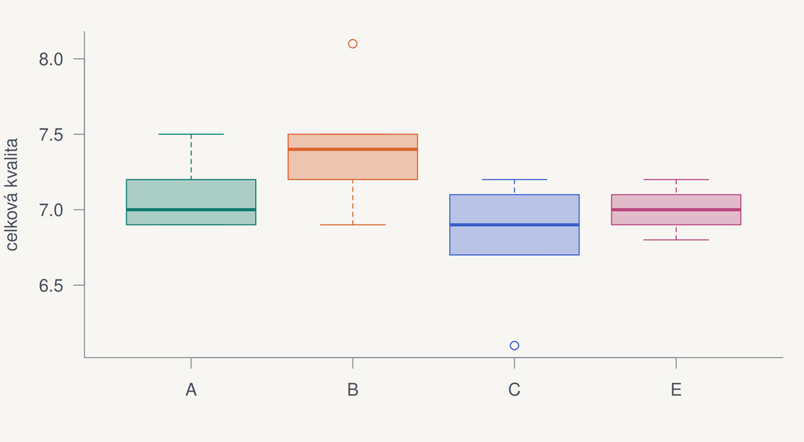

```r
syry <- data.frame(
  A = c(7.5, 6.9, 7, 7, 6.9, 7.1, 7.2, 7.5, 6.9),
  B = c(7.5, 8.1, 7.5, 7.4, 7.1, 7.5, 7.2, 7.2, 6.9),
  C = c(7, 6.1, 6.7, 6.1, 6.9, 7.1, 7.2, 7.2, 6.9),
  E = c(6.8, 6.9, 6.9, 7, 7, 7, 7.1, 7.1, 7.2)
)
boxplot(syry, col = paste0(pal[1:4], "55"),
        border = pal[1:4],
        ylab = "celková kvalita")
```

Hrubá čiara = medián, krabica = stred 50 % dát, body mimo fúzov = odľahlé hodnoty.

## Grafy po vrstvách

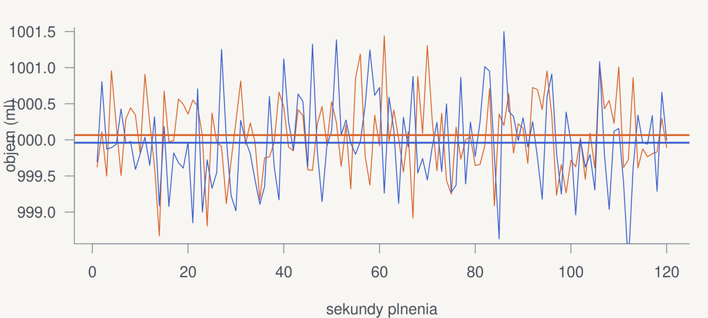

```r
set.seed(1)
linka1 <- rnorm(120, mean = 1000, sd = 0.6)
linka2 <- rnorm(120, mean = 1000, sd = 0.6)
plot(linka1, type = "l", col = pal[2], xlab = "sekundy plnenia", ylab = "objem (ml)")
lines(linka2, col = pal[3])
abline(h = c(mean(linka1), mean(linka2)), col = pal[2:3], lwd = 2)
```

## KVÍZ Vyberte graf

Chcete ukázať vedeniu, že **nová receptúra má menší rozptyl** hodnotení ako stará. Ktorý graf?

**Boxplot** – ukáže medián aj rozptyl (výšku krabice) oboch receptúr vedľa seba. Stĺpcový graf priemerov by rozptyl skryl.

## Zhrnutie

- Senzorické dáta = ľudský merací prístroj → **variabilita** je súčasť merania.
- V R pracujeme so **skriptami** a dátami v **data.frame** (jeden riadok = jedno hodnotenie).
- Priemer vždy s **intervalom spoľahlivosti**, pri malom paneli s t-rozdelením.
- Najprv **graf**, potom test.

Teória 1 Teória 2 Teória 3 Teória 4 [Skripty SK](https://github.com/senzorika/SaIT)